# lesson19_SPSS_Output

[output not shown]

Log  
Log - Log - October 31, 2017

* Encoding: UTF-8.  
* ============================================.  
* LESSON 19 - Logistic Regression  
*  
* Melinda Higgins, PhD  
* dated 10/31/2017  
* ============================================.  
* ============================================.  
* For this lesson we'll use the helpmkh dataset  
*  
* Let's focus on homeless as the main outcome variable  
* which is dichotomous coded 0 and 1. We'll use  
* logistic regression to look at predicting whether someone  
* was homeless or not using these variables  
* age, gender, pss_fr, pcs, mcs, cesd and indtot  
* ============================================.  
* ============================================.  
* let's look at the correlations between these variables  
* ============================================.  
CORRELATIONS  
/VARIABLES=homeless age female pss_fr pcs mcs cesd indtot  
/PRINT=TWOTAIL NOSIG  
/MISSING=PAIRWISE.

Correlations  
Correlations - Correlations - October 31, 2017

CorrelationsCorrelations, table, 1 levels of column headers and 2 levels of row headers, table with 10 columns and 28 rows

|  |  | homeless One or more nights on the street or shelter in past 6 months | age Age at baseline (in years) | female Gender of respondent | pss_fr Perceived Social Support - friends | pcs SF36 Physical Composite Score - Baseline | mcs SF36 Mental Composite Score - Baseline | cesd CESD total score - Baseline | indtot Inventory of Drug Use Consequences (InDue) total score - Baseline |
| --- | --- | --- | --- | --- | --- | --- | --- | --- | --- |
| homeless One or more nights on the street or shelter in past 6 months | Pearson Correlation | 1 | .086 | -.098* | -.173** | -.096* | -.068 | .087 | .216** |
|  | Sig. (2-tailed) |  | .068 | .038 | .000 | .042 | .147 | .064 | .000 |
|  | N | 453 | 453 | 453 | 453 | 453 | 453 | 453 | 453 |
| age Age at baseline (in years) | Pearson Correlation | .086 | 1 | .043 | .080 | -.229** | .045 | .008 | .026 |
|  | Sig. (2-tailed) | .068 |  | .358 | .088 | .000 | .343 | .859 | .575 |
|  | N | 453 | 453 | 453 | 453 | 453 | 453 | 453 | 453 |
| female Gender of respondent | Pearson Correlation | -.098* | .043 | 1 | .067 | -.157** | -.119* | .180** | -.261** |
|  | Sig. (2-tailed) | .038 | .358 |  | .155 | .001 | .011 | .000 | .000 |
|  | N | 453 | 453 | 453 | 453 | 453 | 453 | 453 | 453 |
| pss_fr Perceived Social Support - friends | Pearson Correlation | -.173** | .080 | .067 | 1 | .077 | .138** | -.184** | -.198** |
|  | Sig. (2-tailed) | .000 | .088 | .155 |  | .104 | .003 | .000 | .000 |
|  | N | 453 | 453 | 453 | 453 | 453 | 453 | 453 | 453 |
| pcs SF36 Physical Composite Score - Baseline | Pearson Correlation | -.096* | -.229** | -.157** | .077 | 1 | .110* | -.293** | -.135** |
|  | Sig. (2-tailed) | .042 | .000 | .001 | .104 |  | .019 | .000 | .004 |
|  | N | 453 | 453 | 453 | 453 | 453 | 453 | 453 | 453 |
| mcs SF36 Mental Composite Score - Baseline | Pearson Correlation | -.068 | .045 | -.119* | .138** | .110* | 1 | -.682** | -.381** |
|  | Sig. (2-tailed) | .147 | .343 | .011 | .003 | .019 |  | .000 | .000 |
|  | N | 453 | 453 | 453 | 453 | 453 | 453 | 453 | 453 |
| cesd CESD total score - Baseline | Pearson Correlation | .087 | .008 | .180** | -.184** | -.293** | -.682** | 1 | .336** |
|  | Sig. (2-tailed) | .064 | .859 | .000 | .000 | .000 | .000 |  | .000 |
|  | N | 453 | 453 | 453 | 453 | 453 | 453 | 453 | 453 |
| indtot Inventory of Drug Use Consequences (InDue) total score - Baseline | Pearson Correlation | .216** | .026 | -.261** | -.198** | -.135** | -.381** | .336** | 1 |
|  | Sig. (2-tailed) | .000 | .575 | .000 | .000 | .004 | .000 | .000 |  |
|  | N | 453 | 453 | 453 | 453 | 453 | 453 | 453 | 453 |

*. Correlation is significant at the 0.05 level (2-tailed).  
**. Correlation is significant at the 0.01 level (2-tailed).

Log  
Log - Log - October 31, 2017

NONPAR CORR  
/VARIABLES=homeless age female pss_fr pcs mcs cesd indtot  
/PRINT=SPEARMAN TWOTAIL NOSIG  
/MISSING=PAIRWISE.

Nonparametric Correlations  
Nonparametric Correlations - Correlations - October 31, 2017

CorrelationsCorrelations, table, 1 levels of column headers and 3 levels of row headers, table with 11 columns and 28 rows

|  |  |  | homeless One or more nights on the street or shelter in past 6 months | age Age at baseline (in years) | female Gender of respondent | pss_fr Perceived Social Support - friends | pcs SF36 Physical Composite Score - Baseline | mcs SF36 Mental Composite Score - Baseline | cesd CESD total score - Baseline | indtot Inventory of Drug Use Consequences (InDue) total score - Baseline |
| --- | --- | --- | --- | --- | --- | --- | --- | --- | --- | --- |
| Spearman's rho | homeless One or more nights on the street or shelter in past 6 months | Correlation Coefficient | 1.000 | .083 | -.098* | -.172** | -.107* | -.063 | .105* | .249** |
|  |  | Sig. (2-tailed) | . | .077 | .038 | .000 | .022 | .181 | .026 | .000 |
|  |  | N | 453 | 453 | 453 | 453 | 453 | 453 | 453 | 453 |
|  | age Age at baseline (in years) | Correlation Coefficient | .083 | 1.000 | .040 | .062 | -.207** | .029 | .016 | .066 |
|  |  | Sig. (2-tailed) | .077 | . | .399 | .190 | .000 | .541 | .729 | .163 |
|  |  | N | 453 | 453 | 453 | 453 | 453 | 453 | 453 | 453 |
|  | female Gender of respondent | Correlation Coefficient | -.098* | .040 | 1.000 | .063 | -.169** | -.121* | .183** | -.258** |
|  |  | Sig. (2-tailed) | .038 | .399 | . | .178 | .000 | .010 | .000 | .000 |
|  |  | N | 453 | 453 | 453 | 453 | 453 | 453 | 453 | 453 |
|  | pss_fr Perceived Social Support - friends | Correlation Coefficient | -.172** | .062 | .063 | 1.000 | .067 | .126** | -.183** | -.185** |
|  |  | Sig. (2-tailed) | .000 | .190 | .178 | . | .157 | .007 | .000 | .000 |
|  |  | N | 453 | 453 | 453 | 453 | 453 | 453 | 453 | 453 |
|  | pcs SF36 Physical Composite Score - Baseline | Correlation Coefficient | -.107* | -.207** | -.169** | .067 | 1.000 | .144** | -.299** | -.134** |
|  |  | Sig. (2-tailed) | .022 | .000 | .000 | .157 | . | .002 | .000 | .004 |
|  |  | N | 453 | 453 | 453 | 453 | 453 | 453 | 453 | 453 |
|  | mcs SF36 Mental Composite Score - Baseline | Correlation Coefficient | -.063 | .029 | -.121* | .126** | .144** | 1.000 | -.661** | -.343** |
|  |  | Sig. (2-tailed) | .181 | .541 | .010 | .007 | .002 | . | .000 | .000 |
|  |  | N | 453 | 453 | 453 | 453 | 453 | 453 | 453 | 453 |
|  | cesd CESD total score - Baseline | Correlation Coefficient | .105* | .016 | .183** | -.183** | -.299** | -.661** | 1.000 | .313** |
|  |  | Sig. (2-tailed) | .026 | .729 | .000 | .000 | .000 | .000 | . | .000 |
|  |  | N | 453 | 453 | 453 | 453 | 453 | 453 | 453 | 453 |
|  | indtot Inventory of Drug Use Consequences (InDue) total score - Baseline | Correlation Coefficient | .249** | .066 | -.258** | -.185** | -.134** | -.343** | .313** | 1.000 |
|  |  | Sig. (2-tailed) | .000 | .163 | .000 | .000 | .004 | .000 | .000 | . |
|  |  | N | 453 | 453 | 453 | 453 | 453 | 453 | 453 | 453 |

*. Correlation is significant at the 0.05 level (2-tailed).  
**. Correlation is significant at the 0.01 level (2-tailed).

Log  
Log - Log - October 31, 2017

* ============================================.  
* Given the stronger correlation between indtot  
* and homeless, let's run a t-test to see the comparison  
* ============================================.  
T-TEST GROUPS=homeless(0 1)  
/MISSING=ANALYSIS  
/VARIABLES=indtot  
/CRITERIA=CI(.95).

T-Test  
T-Test - Group Statistics - October 31, 2017

Group StatisticsGroup Statistics, table, 1 levels of column headers and 2 levels of row headers, table with 6 columns and 4 rows

|  | homeless One or more nights on the street or shelter in past 6 months | N | Mean | Std. Deviation | Std. Error Mean |
| --- | --- | --- | --- | --- | --- |
| indtot Inventory of Drug Use Consequences (InDue) total score - Baseline | 0 no | 244 | 34.30 | 7.519 | .481 |
|  | 1 yes | 209 | 37.39 | 6.320 | .437 |

T-Test  
T-Test - Independent Samples Test - October 31, 2017

Independent Samples TestIndependent Samples Test, table, 3 levels of column headers and 2 levels of row headers, table with 11 columns and 6 rows

|  |  | Levene's Test for Equality of Variances |  | t-test for Equality of Means |  |  |  |  |  |  |
| --- | --- | --- | --- | --- | --- | --- | --- | --- | --- | --- |
|  |  | F | Sig. | t | df | Sig. (2-tailed) | Mean Difference | Std. Error Difference | 95% Confidence Interval of the Difference |  |
|  |  |  |  |  |  |  |  |  | Lower | Upper |
| indtot Inventory of Drug Use Consequences (InDue) total score - Baseline | Equal variances assumed | 3.346 | .068 | -4.688 | 451 | .000 | -3.089 | .659 | -4.384 | -1.794 |
|  | Equal variances not assumed |  |  | -4.751 | 450.845 | .000 | -3.089 | .650 | -4.367 | -1.811 |

Log  
Log - Log - October 31, 2017

* ============================================.  
* Let's run a logistic regression of indtot to predict  
* the probability of being homeless  
* we'll also SAVE the predicted probabilities  
* and the predicted group membership  
*  
* NOTE: The current default threshold cutoff is 0.5.  
* ============================================.  
LOGISTIC REGRESSION VARIABLES homeless  
/METHOD=ENTER indtot  
/SAVE=PRED PGROUP  
/PRINT=GOODFIT ITER(1) CI(95)  
/CRITERIA=PIN(0.05) POUT(0.10) ITERATE(20) CUT(0.5).

Logistic Regression  
Logistic Regression - Case Processing Summary - October 31, 2017

Case Processing SummaryCase Processing Summary, table, 1 levels of column headers and 2 levels of row headers, table with 4 columns and 8 rows

| Unweighted Cases<sup>a</sup> |  | N | Percent |
| --- | --- | --- | --- |
| Selected Cases | Included in Analysis | 453 | 100.0 |
|  | Missing Cases | 0 | .0 |
|  | Total | 453 | 100.0 |
| Unselected Cases |  | 0 | .0 |
| Total |  | 453 | 100.0 |

a. If weight is in effect, see classification table for the total number of cases.

Logistic Regression  
Logistic Regression - Dependent Variable Encoding - October 31, 2017

Dependent Variable EncodingDependent Variable Encoding, table, 1 levels of column headers and 1 levels of row headers, table with 2 columns and 4 rows

| Original Value | Internal Value |
| --- | --- |
| 0 no | 0 |
| 1 yes | 1 |

Block 0: Beginning Block  
Block 0: Beginning Block - Iteration History - October 31, 2017

Iteration History<sup>a,b,c</sup>Iteration History, table, 2 levels of column headers and 2 levels of row headers, table with 4 columns and 8 rows

| Iteration |  | -2 Log likelihood | Coefficients |
| --- | --- | --- | --- |
|  |  |  | Constant |
| Step 0 | 1 | 625.284 | -.155 |
|  | 2 | 625.284 | -.155 |

a. Constant is included in the model.  
b. Initial -2 Log Likelihood: 625.284  
c. Estimation terminated at iteration number 2 because parameter estimates changed by less than .001.

Block 0: Beginning Block  
Block 0: Beginning Block - Classification Table - October 31, 2017

Classification Table<sup>a,b</sup>Classification Table, table, 3 levels of column headers and 3 levels of row headers, table with 6 columns and 9 rows

|  | Observed |  | Predicted |  |  |  |
| --- | --- | --- | --- | --- | --- | --- |
|  |  |  | homeless One or more nights on the street or shelter in past 6 months |  | Percentage Correct |  |
|  |  |  | 0 no | 1 yes |  |  |
| Step 0 | homeless One or more nights on the street or shelter in past 6 months | 0 no | 244 | 0 |  | 100.0 |
|  |  | 1 yes | 209 | 0 | .0 |  |
|  | Overall Percentage |  |  |  | 53.9 |  |

a. Constant is included in the model.  
b. The cut value is .500

Block 0: Beginning Block  
Block 0: Beginning Block - Variables in the Equation - October 31, 2017

Variables in the EquationVariables in the Equation, table, 1 levels of column headers and 2 levels of row headers, table with 8 columns and 3 rows

|  |  | B | S.E. | Wald | df | Sig. | Exp(B) |
| --- | --- | --- | --- | --- | --- | --- | --- |
| Step 0 | Constant | -.155 | .094 | 2.699 | 1 | .100 | .857 |

Block 0: Beginning Block  
Block 0: Beginning Block - Variables not in the Equation - October 31, 2017

Variables not in the EquationVariables not in the Equation, table, 1 levels of column headers and 3 levels of row headers, table with 6 columns and 4 rows

|  |  |  | Score | df | Sig. |
| --- | --- | --- | --- | --- | --- |
| Step 0 | Variables | indtot | 21.046 | 1 | .000 |
|  | Overall Statistics |  | 21.046 | 1 | .000 |

Block 1: Method = Enter  
Block 1: Method = Enter - Iteration History - October 31, 2017

Iteration History<sup>a,b,c,d</sup>Iteration History, table, 2 levels of column headers and 2 levels of row headers, table with 5 columns and 11 rows

| Iteration |  | -2 Log likelihood | Coefficients |  |
| --- | --- | --- | --- | --- |
|  |  |  | Constant | indtot |
| Step 1 | 1 | 603.160 | -2.304 | .060 |
|  | 2 | 602.868 | -2.597 | .068 |
|  | 3 | 602.868 | -2.607 | .068 |
|  | 4 | 602.868 | -2.607 | .068 |

a. Method: Enter  
b. Constant is included in the model.  
c. Initial -2 Log Likelihood: 625.284  
d. Estimation terminated at iteration number 4 because parameter estimates changed by less than .001.

Block 1: Method = Enter  
Block 1: Method = Enter - Omnibus Tests of Model Coefficients - October 31, 2017

Omnibus Tests of Model CoefficientsOmnibus Tests of Model Coefficients, table, 1 levels of column headers and 2 levels of row headers, table with 5 columns and 5 rows

|  |  | Chi-square | df | Sig. |
| --- | --- | --- | --- | --- |
| Step 1 | Step | 22.417 | 1 | .000 |
|  | Block | 22.417 | 1 | .000 |
|  | Model | 22.417 | 1 | .000 |

Block 1: Method = Enter  
Block 1: Method = Enter - Model Summary - October 31, 2017

Model SummaryModel Summary, table, 1 levels of column headers and 1 levels of row headers, table with 4 columns and 4 rows

| Step | -2 Log likelihood | Cox & Snell R Square | Nagelkerke R Square |
| --- | --- | --- | --- |
| 1 | 602.868<sup>a</sup> | .048 | .065 |

a. Estimation terminated at iteration number 4 because parameter estimates changed by less than .001.

Block 1: Method = Enter  
Block 1: Method = Enter - Hosmer and Lemeshow Test - October 31, 2017

Hosmer and Lemeshow TestHosmer and Lemeshow Test, table, 1 levels of column headers and 1 levels of row headers, table with 4 columns and 3 rows

| Step | Chi-square | df | Sig. |
| --- | --- | --- | --- |
| 1 | 13.367 | 8 | .100 |

Block 1: Method = Enter  
Block 1: Method = Enter - Contingency Table for Hosmer and Lemeshow Test - October 31, 2017

Contingency Table for Hosmer and Lemeshow TestContingency Table for Hosmer and Lemeshow Test, table, 2 levels of column headers and 2 levels of row headers, table with 7 columns and 13 rows

|  |  | homeless One or more nights on the street or shelter in past 6 months = 0 no |  | homeless One or more nights on the street or shelter in past 6 months = 1 yes |  | Total |  |
| --- | --- | --- | --- | --- | --- | --- | --- |
|  |  | Observed | Expected | Observed | Expected |  |  |
| Step 1 | 1 | 32 | 36.143 | 15 | 10.857 |  | 47 |
|  | 2 | 33 | 32.846 | 18 | 18.154 | 51 |  |
|  | 3 | 24 | 23.302 | 15 | 15.698 | 39 |  |
|  | 4 | 25 | 20.326 | 11 | 15.674 | 36 |  |
|  | 5 | 32 | 28.087 | 21 | 24.913 | 53 |  |
|  | 6 | 20 | 16.663 | 13 | 16.337 | 33 |  |
|  | 7 | 17 | 13.662 | 11 | 14.338 | 28 |  |
|  | 8 | 16 | 17.425 | 21 | 19.575 | 37 |  |
|  | 9 | 17 | 17.707 | 22 | 21.293 | 39 |  |
|  | 10 | 28 | 37.839 | 62 | 52.161 | 90 |  |

Block 1: Method = Enter  
Block 1: Method = Enter - Classification Table - October 31, 2017

Classification Table<sup>a</sup>Classification Table, table, 3 levels of column headers and 3 levels of row headers, table with 6 columns and 8 rows

|  | Observed |  | Predicted |  |  |  |
| --- | --- | --- | --- | --- | --- | --- |
|  |  |  | homeless One or more nights on the street or shelter in past 6 months |  | Percentage Correct |  |
|  |  |  | 0 no | 1 yes |  |  |
| Step 1 | homeless One or more nights on the street or shelter in past 6 months | 0 no | 166 | 78 |  | 68.0 |
|  |  | 1 yes | 93 | 116 | 55.5 |  |
|  | Overall Percentage |  |  |  | 62.3 |  |

a. The cut value is .500

Block 1: Method = Enter  
Block 1: Method = Enter - Variables in the Equation - October 31, 2017

Variables in the EquationVariables in the Equation, table, 2 levels of column headers and 2 levels of row headers, table with 10 columns and 6 rows

|  |  | B | S.E. | Wald | df | Sig. | Exp(B) | 95% C.I.for EXP(B) |  |
| --- | --- | --- | --- | --- | --- | --- | --- | --- | --- |
|  |  |  |  |  |  |  |  | Lower | Upper |
| Step 1<sup>a</sup> | indtot | .068 | .015 | 19.486 | 1 | .000 | 1.070 | 1.039 | 1.103 |
|  | Constant | -2.607 | .569 | 20.952 | 1 | .000 | .074 |  |  |

a. Variable(s) entered on step 1: indtot.

Log  
Log - Log - October 31, 2017

* ============================================.  
* plot the predicted probability of homeless  
* against indtot to see the effect of indtot scores  
* with the predicted probability  
* ============================================.  
GRAPH  
/SCATTERPLOT(BIVAR)=indtot WITH PRE_1  
/MISSING=LISTWISE.

Graph  
Graph - Scatter of PRE_1 indtot - October 31, 2017

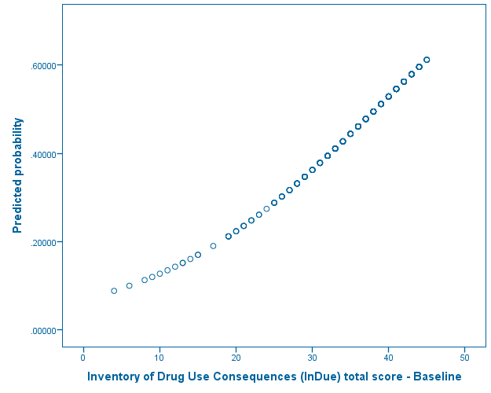

Log  
Log - Log - October 31, 2017

* ============================================.  
* let's look at some other threshold values  
* and we'll compare the classification tables.  
* ============================================.  
LOGISTIC REGRESSION VARIABLES homeless  
/METHOD=ENTER indtot  
/PRINT=GOODFIT ITER(1) CI(95)  
/CRITERIA=PIN(0.05) POUT(0.10) ITERATE(20) CUT(0.2).

Logistic Regression  
Logistic Regression - Case Processing Summary - October 31, 2017

Case Processing SummaryCase Processing Summary, table, 1 levels of column headers and 2 levels of row headers, table with 4 columns and 8 rows

| Unweighted Cases<sup>a</sup> |  | N | Percent |
| --- | --- | --- | --- |
| Selected Cases | Included in Analysis | 453 | 100.0 |
|  | Missing Cases | 0 | .0 |
|  | Total | 453 | 100.0 |
| Unselected Cases |  | 0 | .0 |
| Total |  | 453 | 100.0 |

a. If weight is in effect, see classification table for the total number of cases.

Logistic Regression  
Logistic Regression - Dependent Variable Encoding - October 31, 2017

Dependent Variable EncodingDependent Variable Encoding, table, 1 levels of column headers and 1 levels of row headers, table with 2 columns and 4 rows

| Original Value | Internal Value |
| --- | --- |
| 0 no | 0 |
| 1 yes | 1 |

Block 0: Beginning Block  
Block 0: Beginning Block - Iteration History - October 31, 2017

Iteration History<sup>a,b,c</sup>Iteration History, table, 2 levels of column headers and 2 levels of row headers, table with 4 columns and 8 rows

| Iteration |  | -2 Log likelihood | Coefficients |
| --- | --- | --- | --- |
|  |  |  | Constant |
| Step 0 | 1 | 625.284 | -.155 |
|  | 2 | 625.284 | -.155 |

a. Constant is included in the model.  
b. Initial -2 Log Likelihood: 625.284  
c. Estimation terminated at iteration number 2 because parameter estimates changed by less than .001.

Block 0: Beginning Block  
Block 0: Beginning Block - Classification Table - October 31, 2017

Classification Table<sup>a,b</sup>Classification Table, table, 3 levels of column headers and 3 levels of row headers, table with 6 columns and 9 rows

|  | Observed |  | Predicted |  |  |  |
| --- | --- | --- | --- | --- | --- | --- |
|  |  |  | homeless One or more nights on the street or shelter in past 6 months |  | Percentage Correct |  |
|  |  |  | 0 no | 1 yes |  |  |
| Step 0 | homeless One or more nights on the street or shelter in past 6 months | 0 no | 0 | 244 |  | .0 |
|  |  | 1 yes | 0 | 209 | 100.0 |  |
|  | Overall Percentage |  |  |  | 46.1 |  |

a. Constant is included in the model.  
b. The cut value is .200

Block 0: Beginning Block  
Block 0: Beginning Block - Variables in the Equation - October 31, 2017

Variables in the EquationVariables in the Equation, table, 1 levels of column headers and 2 levels of row headers, table with 8 columns and 3 rows

|  |  | B | S.E. | Wald | df | Sig. | Exp(B) |
| --- | --- | --- | --- | --- | --- | --- | --- |
| Step 0 | Constant | -.155 | .094 | 2.699 | 1 | .100 | .857 |

Block 0: Beginning Block  
Block 0: Beginning Block - Variables not in the Equation - October 31, 2017

Variables not in the EquationVariables not in the Equation, table, 1 levels of column headers and 3 levels of row headers, table with 6 columns and 4 rows

|  |  |  | Score | df | Sig. |
| --- | --- | --- | --- | --- | --- |
| Step 0 | Variables | indtot | 21.046 | 1 | .000 |
|  | Overall Statistics |  | 21.046 | 1 | .000 |

Block 1: Method = Enter  
Block 1: Method = Enter - Iteration History - October 31, 2017

Iteration History<sup>a,b,c,d</sup>Iteration History, table, 2 levels of column headers and 2 levels of row headers, table with 5 columns and 11 rows

| Iteration |  | -2 Log likelihood | Coefficients |  |
| --- | --- | --- | --- | --- |
|  |  |  | Constant | indtot |
| Step 1 | 1 | 603.160 | -2.304 | .060 |
|  | 2 | 602.868 | -2.597 | .068 |
|  | 3 | 602.868 | -2.607 | .068 |
|  | 4 | 602.868 | -2.607 | .068 |

a. Method: Enter  
b. Constant is included in the model.  
c. Initial -2 Log Likelihood: 625.284  
d. Estimation terminated at iteration number 4 because parameter estimates changed by less than .001.

Block 1: Method = Enter  
Block 1: Method = Enter - Omnibus Tests of Model Coefficients - October 31, 2017

Omnibus Tests of Model CoefficientsOmnibus Tests of Model Coefficients, table, 1 levels of column headers and 2 levels of row headers, table with 5 columns and 5 rows

|  |  | Chi-square | df | Sig. |
| --- | --- | --- | --- | --- |
| Step 1 | Step | 22.417 | 1 | .000 |
|  | Block | 22.417 | 1 | .000 |
|  | Model | 22.417 | 1 | .000 |

Block 1: Method = Enter  
Block 1: Method = Enter - Model Summary - October 31, 2017

Model SummaryModel Summary, table, 1 levels of column headers and 1 levels of row headers, table with 4 columns and 4 rows

| Step | -2 Log likelihood | Cox & Snell R Square | Nagelkerke R Square |
| --- | --- | --- | --- |
| 1 | 602.868<sup>a</sup> | .048 | .065 |

a. Estimation terminated at iteration number 4 because parameter estimates changed by less than .001.

Block 1: Method = Enter  
Block 1: Method = Enter - Hosmer and Lemeshow Test - October 31, 2017

Hosmer and Lemeshow TestHosmer and Lemeshow Test, table, 1 levels of column headers and 1 levels of row headers, table with 4 columns and 3 rows

| Step | Chi-square | df | Sig. |
| --- | --- | --- | --- |
| 1 | 13.367 | 8 | .100 |

Block 1: Method = Enter  
Block 1: Method = Enter - Contingency Table for Hosmer and Lemeshow Test - October 31, 2017

Contingency Table for Hosmer and Lemeshow TestContingency Table for Hosmer and Lemeshow Test, table, 2 levels of column headers and 2 levels of row headers, table with 7 columns and 13 rows

|  |  | homeless One or more nights on the street or shelter in past 6 months = 0 no |  | homeless One or more nights on the street or shelter in past 6 months = 1 yes |  | Total |  |
| --- | --- | --- | --- | --- | --- | --- | --- |
|  |  | Observed | Expected | Observed | Expected |  |  |
| Step 1 | 1 | 32 | 36.143 | 15 | 10.857 |  | 47 |
|  | 2 | 33 | 32.846 | 18 | 18.154 | 51 |  |
|  | 3 | 24 | 23.302 | 15 | 15.698 | 39 |  |
|  | 4 | 25 | 20.326 | 11 | 15.674 | 36 |  |
|  | 5 | 32 | 28.087 | 21 | 24.913 | 53 |  |
|  | 6 | 20 | 16.663 | 13 | 16.337 | 33 |  |
|  | 7 | 17 | 13.662 | 11 | 14.338 | 28 |  |
|  | 8 | 16 | 17.425 | 21 | 19.575 | 37 |  |
|  | 9 | 17 | 17.707 | 22 | 21.293 | 39 |  |
|  | 10 | 28 | 37.839 | 62 | 52.161 | 90 |  |

Block 1: Method = Enter  
Block 1: Method = Enter - Classification Table - October 31, 2017

Classification Table<sup>a</sup>Classification Table, table, 3 levels of column headers and 3 levels of row headers, table with 6 columns and 8 rows

|  | Observed |  | Predicted |  |  |  |
| --- | --- | --- | --- | --- | --- | --- |
|  |  |  | homeless One or more nights on the street or shelter in past 6 months |  | Percentage Correct |  |
|  |  |  | 0 no | 1 yes |  |  |
| Step 1 | homeless One or more nights on the street or shelter in past 6 months | 0 no | 10 | 234 |  | 4.1 |
|  |  | 1 yes | 3 | 206 | 98.6 |  |
|  | Overall Percentage |  |  |  | 47.7 |  |

a. The cut value is .200

Block 1: Method = Enter  
Block 1: Method = Enter - Variables in the Equation - October 31, 2017

Variables in the EquationVariables in the Equation, table, 2 levels of column headers and 2 levels of row headers, table with 10 columns and 6 rows

|  |  | B | S.E. | Wald | df | Sig. | Exp(B) | 95% C.I.for EXP(B) |  |
| --- | --- | --- | --- | --- | --- | --- | --- | --- | --- |
|  |  |  |  |  |  |  |  | Lower | Upper |
| Step 1<sup>a</sup> | indtot | .068 | .015 | 19.486 | 1 | .000 | 1.070 | 1.039 | 1.103 |
|  | Constant | -2.607 | .569 | 20.952 | 1 | .000 | .074 |  |  |

a. Variable(s) entered on step 1: indtot.

Log  
Log - Log - October 31, 2017

LOGISTIC REGRESSION VARIABLES homeless  
/METHOD=ENTER indtot  
/PRINT=GOODFIT ITER(1) CI(95)  
/CRITERIA=PIN(0.05) POUT(0.10) ITERATE(20) CUT(0.4).

Logistic Regression  
Logistic Regression - Case Processing Summary - October 31, 2017

Case Processing SummaryCase Processing Summary, table, 1 levels of column headers and 2 levels of row headers, table with 4 columns and 8 rows

| Unweighted Cases<sup>a</sup> |  | N | Percent |
| --- | --- | --- | --- |
| Selected Cases | Included in Analysis | 453 | 100.0 |
|  | Missing Cases | 0 | .0 |
|  | Total | 453 | 100.0 |
| Unselected Cases |  | 0 | .0 |
| Total |  | 453 | 100.0 |

a. If weight is in effect, see classification table for the total number of cases.

Logistic Regression  
Logistic Regression - Dependent Variable Encoding - October 31, 2017

Dependent Variable EncodingDependent Variable Encoding, table, 1 levels of column headers and 1 levels of row headers, table with 2 columns and 4 rows

| Original Value | Internal Value |
| --- | --- |
| 0 no | 0 |
| 1 yes | 1 |

Block 0: Beginning Block  
Block 0: Beginning Block - Iteration History - October 31, 2017

Iteration History<sup>a,b,c</sup>Iteration History, table, 2 levels of column headers and 2 levels of row headers, table with 4 columns and 8 rows

| Iteration |  | -2 Log likelihood | Coefficients |
| --- | --- | --- | --- |
|  |  |  | Constant |
| Step 0 | 1 | 625.284 | -.155 |
|  | 2 | 625.284 | -.155 |

a. Constant is included in the model.  
b. Initial -2 Log Likelihood: 625.284  
c. Estimation terminated at iteration number 2 because parameter estimates changed by less than .001.

Block 0: Beginning Block  
Block 0: Beginning Block - Classification Table - October 31, 2017

Classification Table<sup>a,b</sup>Classification Table, table, 3 levels of column headers and 3 levels of row headers, table with 6 columns and 9 rows

|  | Observed |  | Predicted |  |  |  |
| --- | --- | --- | --- | --- | --- | --- |
|  |  |  | homeless One or more nights on the street or shelter in past 6 months |  | Percentage Correct |  |
|  |  |  | 0 no | 1 yes |  |  |
| Step 0 | homeless One or more nights on the street or shelter in past 6 months | 0 no | 0 | 244 |  | .0 |
|  |  | 1 yes | 0 | 209 | 100.0 |  |
|  | Overall Percentage |  |  |  | 46.1 |  |

a. Constant is included in the model.  
b. The cut value is .400

Block 0: Beginning Block  
Block 0: Beginning Block - Variables in the Equation - October 31, 2017

Variables in the EquationVariables in the Equation, table, 1 levels of column headers and 2 levels of row headers, table with 8 columns and 3 rows

|  |  | B | S.E. | Wald | df | Sig. | Exp(B) |
| --- | --- | --- | --- | --- | --- | --- | --- |
| Step 0 | Constant | -.155 | .094 | 2.699 | 1 | .100 | .857 |

Block 0: Beginning Block  
Block 0: Beginning Block - Variables not in the Equation - October 31, 2017

Variables not in the EquationVariables not in the Equation, table, 1 levels of column headers and 3 levels of row headers, table with 6 columns and 4 rows

|  |  |  | Score | df | Sig. |
| --- | --- | --- | --- | --- | --- |
| Step 0 | Variables | indtot | 21.046 | 1 | .000 |
|  | Overall Statistics |  | 21.046 | 1 | .000 |

Block 1: Method = Enter  
Block 1: Method = Enter - Iteration History - October 31, 2017

Iteration History<sup>a,b,c,d</sup>Iteration History, table, 2 levels of column headers and 2 levels of row headers, table with 5 columns and 11 rows

| Iteration |  | -2 Log likelihood | Coefficients |  |
| --- | --- | --- | --- | --- |
|  |  |  | Constant | indtot |
| Step 1 | 1 | 603.160 | -2.304 | .060 |
|  | 2 | 602.868 | -2.597 | .068 |
|  | 3 | 602.868 | -2.607 | .068 |
|  | 4 | 602.868 | -2.607 | .068 |

a. Method: Enter  
b. Constant is included in the model.  
c. Initial -2 Log Likelihood: 625.284  
d. Estimation terminated at iteration number 4 because parameter estimates changed by less than .001.

Block 1: Method = Enter  
Block 1: Method = Enter - Omnibus Tests of Model Coefficients - October 31, 2017

Omnibus Tests of Model CoefficientsOmnibus Tests of Model Coefficients, table, 1 levels of column headers and 2 levels of row headers, table with 5 columns and 5 rows

|  |  | Chi-square | df | Sig. |
| --- | --- | --- | --- | --- |
| Step 1 | Step | 22.417 | 1 | .000 |
|  | Block | 22.417 | 1 | .000 |
|  | Model | 22.417 | 1 | .000 |

Block 1: Method = Enter  
Block 1: Method = Enter - Model Summary - October 31, 2017

Model SummaryModel Summary, table, 1 levels of column headers and 1 levels of row headers, table with 4 columns and 4 rows

| Step | -2 Log likelihood | Cox & Snell R Square | Nagelkerke R Square |
| --- | --- | --- | --- |
| 1 | 602.868<sup>a</sup> | .048 | .065 |

a. Estimation terminated at iteration number 4 because parameter estimates changed by less than .001.

Block 1: Method = Enter  
Block 1: Method = Enter - Hosmer and Lemeshow Test - October 31, 2017

Hosmer and Lemeshow TestHosmer and Lemeshow Test, table, 1 levels of column headers and 1 levels of row headers, table with 4 columns and 3 rows

| Step | Chi-square | df | Sig. |
| --- | --- | --- | --- |
| 1 | 13.367 | 8 | .100 |

Block 1: Method = Enter  
Block 1: Method = Enter - Contingency Table for Hosmer and Lemeshow Test - October 31, 2017

Contingency Table for Hosmer and Lemeshow TestContingency Table for Hosmer and Lemeshow Test, table, 2 levels of column headers and 2 levels of row headers, table with 7 columns and 13 rows

|  |  | homeless One or more nights on the street or shelter in past 6 months = 0 no |  | homeless One or more nights on the street or shelter in past 6 months = 1 yes |  | Total |  |
| --- | --- | --- | --- | --- | --- | --- | --- |
|  |  | Observed | Expected | Observed | Expected |  |  |
| Step 1 | 1 | 32 | 36.143 | 15 | 10.857 |  | 47 |
|  | 2 | 33 | 32.846 | 18 | 18.154 | 51 |  |
|  | 3 | 24 | 23.302 | 15 | 15.698 | 39 |  |
|  | 4 | 25 | 20.326 | 11 | 15.674 | 36 |  |
|  | 5 | 32 | 28.087 | 21 | 24.913 | 53 |  |
|  | 6 | 20 | 16.663 | 13 | 16.337 | 33 |  |
|  | 7 | 17 | 13.662 | 11 | 14.338 | 28 |  |
|  | 8 | 16 | 17.425 | 21 | 19.575 | 37 |  |
|  | 9 | 17 | 17.707 | 22 | 21.293 | 39 |  |
|  | 10 | 28 | 37.839 | 62 | 52.161 | 90 |  |

Block 1: Method = Enter  
Block 1: Method = Enter - Classification Table - October 31, 2017

Classification Table<sup>a</sup>Classification Table, table, 3 levels of column headers and 3 levels of row headers, table with 6 columns and 8 rows

|  | Observed |  | Predicted |  |  |  |
| --- | --- | --- | --- | --- | --- | --- |
|  |  |  | homeless One or more nights on the street or shelter in past 6 months |  | Percentage Correct |  |
|  |  |  | 0 no | 1 yes |  |  |
| Step 1 | homeless One or more nights on the street or shelter in past 6 months | 0 no | 77 | 167 |  | 31.6 |
|  |  | 1 yes | 41 | 168 | 80.4 |  |
|  | Overall Percentage |  |  |  | 54.1 |  |

a. The cut value is .400

Block 1: Method = Enter  
Block 1: Method = Enter - Variables in the Equation - October 31, 2017

Variables in the EquationVariables in the Equation, table, 2 levels of column headers and 2 levels of row headers, table with 10 columns and 6 rows

|  |  | B | S.E. | Wald | df | Sig. | Exp(B) | 95% C.I.for EXP(B) |  |
| --- | --- | --- | --- | --- | --- | --- | --- | --- | --- |
|  |  |  |  |  |  |  |  | Lower | Upper |
| Step 1<sup>a</sup> | indtot | .068 | .015 | 19.486 | 1 | .000 | 1.070 | 1.039 | 1.103 |
|  | Constant | -2.607 | .569 | 20.952 | 1 | .000 | .074 |  |  |

a. Variable(s) entered on step 1: indtot.

Log  
Log - Log - October 31, 2017

LOGISTIC REGRESSION VARIABLES homeless  
/METHOD=ENTER indtot  
/PRINT=GOODFIT ITER(1) CI(95)  
/CRITERIA=PIN(0.05) POUT(0.10) ITERATE(20) CUT(0.6).

Logistic Regression  
Logistic Regression - Case Processing Summary - October 31, 2017

Case Processing SummaryCase Processing Summary, table, 1 levels of column headers and 2 levels of row headers, table with 4 columns and 8 rows

| Unweighted Cases<sup>a</sup> |  | N | Percent |
| --- | --- | --- | --- |
| Selected Cases | Included in Analysis | 453 | 100.0 |
|  | Missing Cases | 0 | .0 |
|  | Total | 453 | 100.0 |
| Unselected Cases |  | 0 | .0 |
| Total |  | 453 | 100.0 |

a. If weight is in effect, see classification table for the total number of cases.

Logistic Regression  
Logistic Regression - Dependent Variable Encoding - October 31, 2017

Dependent Variable EncodingDependent Variable Encoding, table, 1 levels of column headers and 1 levels of row headers, table with 2 columns and 4 rows

| Original Value | Internal Value |
| --- | --- |
| 0 no | 0 |
| 1 yes | 1 |

Block 0: Beginning Block  
Block 0: Beginning Block - Iteration History - October 31, 2017

Iteration History<sup>a,b,c</sup>Iteration History, table, 2 levels of column headers and 2 levels of row headers, table with 4 columns and 8 rows

| Iteration |  | -2 Log likelihood | Coefficients |
| --- | --- | --- | --- |
|  |  |  | Constant |
| Step 0 | 1 | 625.284 | -.155 |
|  | 2 | 625.284 | -.155 |

a. Constant is included in the model.  
b. Initial -2 Log Likelihood: 625.284  
c. Estimation terminated at iteration number 2 because parameter estimates changed by less than .001.

Block 0: Beginning Block  
Block 0: Beginning Block - Classification Table - October 31, 2017

Classification Table<sup>a,b</sup>Classification Table, table, 3 levels of column headers and 3 levels of row headers, table with 6 columns and 9 rows

|  | Observed |  | Predicted |  |  |  |
| --- | --- | --- | --- | --- | --- | --- |
|  |  |  | homeless One or more nights on the street or shelter in past 6 months |  | Percentage Correct |  |
|  |  |  | 0 no | 1 yes |  |  |
| Step 0 | homeless One or more nights on the street or shelter in past 6 months | 0 no | 244 | 0 |  | 100.0 |
|  |  | 1 yes | 209 | 0 | .0 |  |
|  | Overall Percentage |  |  |  | 53.9 |  |

a. Constant is included in the model.  
b. The cut value is .600

Block 0: Beginning Block  
Block 0: Beginning Block - Variables in the Equation - October 31, 2017

Variables in the EquationVariables in the Equation, table, 1 levels of column headers and 2 levels of row headers, table with 8 columns and 3 rows

|  |  | B | S.E. | Wald | df | Sig. | Exp(B) |
| --- | --- | --- | --- | --- | --- | --- | --- |
| Step 0 | Constant | -.155 | .094 | 2.699 | 1 | .100 | .857 |

Block 0: Beginning Block  
Block 0: Beginning Block - Variables not in the Equation - October 31, 2017

Variables not in the EquationVariables not in the Equation, table, 1 levels of column headers and 3 levels of row headers, table with 6 columns and 4 rows

|  |  |  | Score | df | Sig. |
| --- | --- | --- | --- | --- | --- |
| Step 0 | Variables | indtot | 21.046 | 1 | .000 |
|  | Overall Statistics |  | 21.046 | 1 | .000 |

Block 1: Method = Enter  
Block 1: Method = Enter - Iteration History - October 31, 2017

Iteration History<sup>a,b,c,d</sup>Iteration History, table, 2 levels of column headers and 2 levels of row headers, table with 5 columns and 11 rows

| Iteration |  | -2 Log likelihood | Coefficients |  |
| --- | --- | --- | --- | --- |
|  |  |  | Constant | indtot |
| Step 1 | 1 | 603.160 | -2.304 | .060 |
|  | 2 | 602.868 | -2.597 | .068 |
|  | 3 | 602.868 | -2.607 | .068 |
|  | 4 | 602.868 | -2.607 | .068 |

a. Method: Enter  
b. Constant is included in the model.  
c. Initial -2 Log Likelihood: 625.284  
d. Estimation terminated at iteration number 4 because parameter estimates changed by less than .001.

Block 1: Method = Enter  
Block 1: Method = Enter - Omnibus Tests of Model Coefficients - October 31, 2017

Omnibus Tests of Model CoefficientsOmnibus Tests of Model Coefficients, table, 1 levels of column headers and 2 levels of row headers, table with 5 columns and 5 rows

|  |  | Chi-square | df | Sig. |
| --- | --- | --- | --- | --- |
| Step 1 | Step | 22.417 | 1 | .000 |
|  | Block | 22.417 | 1 | .000 |
|  | Model | 22.417 | 1 | .000 |

Block 1: Method = Enter  
Block 1: Method = Enter - Model Summary - October 31, 2017

Model SummaryModel Summary, table, 1 levels of column headers and 1 levels of row headers, table with 4 columns and 4 rows

| Step | -2 Log likelihood | Cox & Snell R Square | Nagelkerke R Square |
| --- | --- | --- | --- |
| 1 | 602.868<sup>a</sup> | .048 | .065 |

a. Estimation terminated at iteration number 4 because parameter estimates changed by less than .001.

Block 1: Method = Enter  
Block 1: Method = Enter - Hosmer and Lemeshow Test - October 31, 2017

Hosmer and Lemeshow TestHosmer and Lemeshow Test, table, 1 levels of column headers and 1 levels of row headers, table with 4 columns and 3 rows

| Step | Chi-square | df | Sig. |
| --- | --- | --- | --- |
| 1 | 13.367 | 8 | .100 |

Block 1: Method = Enter  
Block 1: Method = Enter - Contingency Table for Hosmer and Lemeshow Test - October 31, 2017

Contingency Table for Hosmer and Lemeshow TestContingency Table for Hosmer and Lemeshow Test, table, 2 levels of column headers and 2 levels of row headers, table with 7 columns and 13 rows

|  |  | homeless One or more nights on the street or shelter in past 6 months = 0 no |  | homeless One or more nights on the street or shelter in past 6 months = 1 yes |  | Total |  |
| --- | --- | --- | --- | --- | --- | --- | --- |
|  |  | Observed | Expected | Observed | Expected |  |  |
| Step 1 | 1 | 32 | 36.143 | 15 | 10.857 |  | 47 |
|  | 2 | 33 | 32.846 | 18 | 18.154 | 51 |  |
|  | 3 | 24 | 23.302 | 15 | 15.698 | 39 |  |
|  | 4 | 25 | 20.326 | 11 | 15.674 | 36 |  |
|  | 5 | 32 | 28.087 | 21 | 24.913 | 53 |  |
|  | 6 | 20 | 16.663 | 13 | 16.337 | 33 |  |
|  | 7 | 17 | 13.662 | 11 | 14.338 | 28 |  |
|  | 8 | 16 | 17.425 | 21 | 19.575 | 37 |  |
|  | 9 | 17 | 17.707 | 22 | 21.293 | 39 |  |
|  | 10 | 28 | 37.839 | 62 | 52.161 | 90 |  |

Block 1: Method = Enter  
Block 1: Method = Enter - Classification Table - October 31, 2017

Classification Table<sup>a</sup>Classification Table, table, 3 levels of column headers and 3 levels of row headers, table with 6 columns and 8 rows

|  | Observed |  | Predicted |  |  |  |
| --- | --- | --- | --- | --- | --- | --- |
|  |  |  | homeless One or more nights on the street or shelter in past 6 months |  | Percentage Correct |  |
|  |  |  | 0 no | 1 yes |  |  |
| Step 1 | homeless One or more nights on the street or shelter in past 6 months | 0 no | 242 | 2 |  | 99.2 |
|  |  | 1 yes | 206 | 3 | 1.4 |  |
|  | Overall Percentage |  |  |  | 54.1 |  |

a. The cut value is .600

Block 1: Method = Enter  
Block 1: Method = Enter - Variables in the Equation - October 31, 2017

Variables in the EquationVariables in the Equation, table, 2 levels of column headers and 2 levels of row headers, table with 10 columns and 6 rows

|  |  | B | S.E. | Wald | df | Sig. | Exp(B) | 95% C.I.for EXP(B) |  |
| --- | --- | --- | --- | --- | --- | --- | --- | --- | --- |
|  |  |  |  |  |  |  |  | Lower | Upper |
| Step 1<sup>a</sup> | indtot | .068 | .015 | 19.486 | 1 | .000 | 1.070 | 1.039 | 1.103 |
|  | Constant | -2.607 | .569 | 20.952 | 1 | .000 | .074 |  |  |

a. Variable(s) entered on step 1: indtot.

Log  
Log - Log - October 31, 2017

LOGISTIC REGRESSION VARIABLES homeless  
/METHOD=ENTER indtot  
/PRINT=GOODFIT ITER(1) CI(95)  
/CRITERIA=PIN(0.05) POUT(0.10) ITERATE(20) CUT(0.8).

Logistic Regression  
Logistic Regression - Case Processing Summary - October 31, 2017

Case Processing SummaryCase Processing Summary, table, 1 levels of column headers and 2 levels of row headers, table with 4 columns and 8 rows

| Unweighted Cases<sup>a</sup> |  | N | Percent |
| --- | --- | --- | --- |
| Selected Cases | Included in Analysis | 453 | 100.0 |
|  | Missing Cases | 0 | .0 |
|  | Total | 453 | 100.0 |
| Unselected Cases |  | 0 | .0 |
| Total |  | 453 | 100.0 |

a. If weight is in effect, see classification table for the total number of cases.

Logistic Regression  
Logistic Regression - Dependent Variable Encoding - October 31, 2017

Dependent Variable EncodingDependent Variable Encoding, table, 1 levels of column headers and 1 levels of row headers, table with 2 columns and 4 rows

| Original Value | Internal Value |
| --- | --- |
| 0 no | 0 |
| 1 yes | 1 |

Block 0: Beginning Block  
Block 0: Beginning Block - Iteration History - October 31, 2017

Iteration History<sup>a,b,c</sup>Iteration History, table, 2 levels of column headers and 2 levels of row headers, table with 4 columns and 8 rows

| Iteration |  | -2 Log likelihood | Coefficients |
| --- | --- | --- | --- |
|  |  |  | Constant |
| Step 0 | 1 | 625.284 | -.155 |
|  | 2 | 625.284 | -.155 |

a. Constant is included in the model.  
b. Initial -2 Log Likelihood: 625.284  
c. Estimation terminated at iteration number 2 because parameter estimates changed by less than .001.

Block 0: Beginning Block  
Block 0: Beginning Block - Classification Table - October 31, 2017

Classification Table<sup>a,b</sup>Classification Table, table, 3 levels of column headers and 3 levels of row headers, table with 6 columns and 9 rows

|  | Observed |  | Predicted |  |  |  |
| --- | --- | --- | --- | --- | --- | --- |
|  |  |  | homeless One or more nights on the street or shelter in past 6 months |  | Percentage Correct |  |
|  |  |  | 0 no | 1 yes |  |  |
| Step 0 | homeless One or more nights on the street or shelter in past 6 months | 0 no | 244 | 0 |  | 100.0 |
|  |  | 1 yes | 209 | 0 | .0 |  |
|  | Overall Percentage |  |  |  | 53.9 |  |

a. Constant is included in the model.  
b. The cut value is .800

Block 0: Beginning Block  
Block 0: Beginning Block - Variables in the Equation - October 31, 2017

Variables in the EquationVariables in the Equation, table, 1 levels of column headers and 2 levels of row headers, table with 8 columns and 3 rows

|  |  | B | S.E. | Wald | df | Sig. | Exp(B) |
| --- | --- | --- | --- | --- | --- | --- | --- |
| Step 0 | Constant | -.155 | .094 | 2.699 | 1 | .100 | .857 |

Block 0: Beginning Block  
Block 0: Beginning Block - Variables not in the Equation - October 31, 2017

Variables not in the EquationVariables not in the Equation, table, 1 levels of column headers and 3 levels of row headers, table with 6 columns and 4 rows

|  |  |  | Score | df | Sig. |
| --- | --- | --- | --- | --- | --- |
| Step 0 | Variables | indtot | 21.046 | 1 | .000 |
|  | Overall Statistics |  | 21.046 | 1 | .000 |

Block 1: Method = Enter  
Block 1: Method = Enter - Iteration History - October 31, 2017

Iteration History<sup>a,b,c,d</sup>Iteration History, table, 2 levels of column headers and 2 levels of row headers, table with 5 columns and 11 rows

| Iteration |  | -2 Log likelihood | Coefficients |  |
| --- | --- | --- | --- | --- |
|  |  |  | Constant | indtot |
| Step 1 | 1 | 603.160 | -2.304 | .060 |
|  | 2 | 602.868 | -2.597 | .068 |
|  | 3 | 602.868 | -2.607 | .068 |
|  | 4 | 602.868 | -2.607 | .068 |

a. Method: Enter  
b. Constant is included in the model.  
c. Initial -2 Log Likelihood: 625.284  
d. Estimation terminated at iteration number 4 because parameter estimates changed by less than .001.

Block 1: Method = Enter  
Block 1: Method = Enter - Omnibus Tests of Model Coefficients - October 31, 2017

Omnibus Tests of Model CoefficientsOmnibus Tests of Model Coefficients, table, 1 levels of column headers and 2 levels of row headers, table with 5 columns and 5 rows

|  |  | Chi-square | df | Sig. |
| --- | --- | --- | --- | --- |
| Step 1 | Step | 22.417 | 1 | .000 |
|  | Block | 22.417 | 1 | .000 |
|  | Model | 22.417 | 1 | .000 |

Block 1: Method = Enter  
Block 1: Method = Enter - Model Summary - October 31, 2017

Model SummaryModel Summary, table, 1 levels of column headers and 1 levels of row headers, table with 4 columns and 4 rows

| Step | -2 Log likelihood | Cox & Snell R Square | Nagelkerke R Square |
| --- | --- | --- | --- |
| 1 | 602.868<sup>a</sup> | .048 | .065 |

a. Estimation terminated at iteration number 4 because parameter estimates changed by less than .001.

Block 1: Method = Enter  
Block 1: Method = Enter - Hosmer and Lemeshow Test - October 31, 2017

Hosmer and Lemeshow TestHosmer and Lemeshow Test, table, 1 levels of column headers and 1 levels of row headers, table with 4 columns and 3 rows

| Step | Chi-square | df | Sig. |
| --- | --- | --- | --- |
| 1 | 13.367 | 8 | .100 |

Block 1: Method = Enter  
Block 1: Method = Enter - Contingency Table for Hosmer and Lemeshow Test - October 31, 2017

Contingency Table for Hosmer and Lemeshow TestContingency Table for Hosmer and Lemeshow Test, table, 2 levels of column headers and 2 levels of row headers, table with 7 columns and 13 rows

|  |  | homeless One or more nights on the street or shelter in past 6 months = 0 no |  | homeless One or more nights on the street or shelter in past 6 months = 1 yes |  | Total |  |
| --- | --- | --- | --- | --- | --- | --- | --- |
|  |  | Observed | Expected | Observed | Expected |  |  |
| Step 1 | 1 | 32 | 36.143 | 15 | 10.857 |  | 47 |
|  | 2 | 33 | 32.846 | 18 | 18.154 | 51 |  |
|  | 3 | 24 | 23.302 | 15 | 15.698 | 39 |  |
|  | 4 | 25 | 20.326 | 11 | 15.674 | 36 |  |
|  | 5 | 32 | 28.087 | 21 | 24.913 | 53 |  |
|  | 6 | 20 | 16.663 | 13 | 16.337 | 33 |  |
|  | 7 | 17 | 13.662 | 11 | 14.338 | 28 |  |
|  | 8 | 16 | 17.425 | 21 | 19.575 | 37 |  |
|  | 9 | 17 | 17.707 | 22 | 21.293 | 39 |  |
|  | 10 | 28 | 37.839 | 62 | 52.161 | 90 |  |

Block 1: Method = Enter  
Block 1: Method = Enter - Classification Table - October 31, 2017

Classification Table<sup>a</sup>Classification Table, table, 3 levels of column headers and 3 levels of row headers, table with 6 columns and 8 rows

|  | Observed |  | Predicted |  |  |  |
| --- | --- | --- | --- | --- | --- | --- |
|  |  |  | homeless One or more nights on the street or shelter in past 6 months |  | Percentage Correct |  |
|  |  |  | 0 no | 1 yes |  |  |
| Step 1 | homeless One or more nights on the street or shelter in past 6 months | 0 no | 244 | 0 |  | 100.0 |
|  |  | 1 yes | 209 | 0 | .0 |  |
|  | Overall Percentage |  |  |  | 53.9 |  |

a. The cut value is .800

Block 1: Method = Enter  
Block 1: Method = Enter - Variables in the Equation - October 31, 2017

Variables in the EquationVariables in the Equation, table, 2 levels of column headers and 2 levels of row headers, table with 10 columns and 6 rows

|  |  | B | S.E. | Wald | df | Sig. | Exp(B) | 95% C.I.for EXP(B) |  |
| --- | --- | --- | --- | --- | --- | --- | --- | --- | --- |
|  |  |  |  |  |  |  |  | Lower | Upper |
| Step 1<sup>a</sup> | indtot | .068 | .015 | 19.486 | 1 | .000 | 1.070 | 1.039 | 1.103 |
|  | Constant | -2.607 | .569 | 20.952 | 1 | .000 | .074 |  |  |

a. Variable(s) entered on step 1: indtot.

Log  
Log - Log - October 31, 2017

* ============================================.  
* another way to look at these tradeoofs is to run  
* a ROC (receiver operating characteristic) curve  
* let's look at one for indtot for homeless  
* ============================================.  
ROC indtot BY homeless (1)  
/PLOT=CURVE(REFERENCE)  
/PRINT=SE COORDINATES  
/CRITERIA=CUTOFF(INCLUDE) TESTPOS(LARGE) DISTRIBUTION(FREE) CI(95)  
/MISSING=EXCLUDE.

ROC Curve  
ROC Curve - Case Processing Summary - October 31, 2017

Case Processing SummaryCase Processing Summary, table, 1 levels of column headers and 1 levels of row headers, table with 2 columns and 6 rows

| homeless One or more nights on the street or shelter in past 6 months | Valid N (listwise) |
| --- | --- |
| Positive<sup>a</sup> | 209 |
| Negative | 244 |

Larger values of the test result variable(s) indicate stronger evidence for a positive actual state.  
a. The positive actual state is 1 yes.

ROC Curve  
ROC Curve - ROC Curve - October 31, 2017

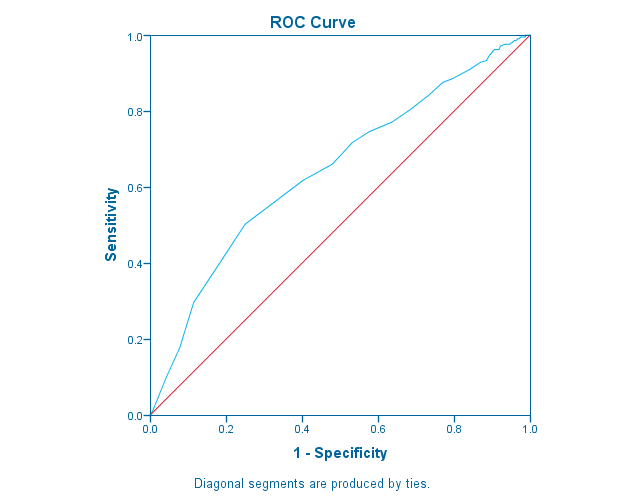

ROC Curve  
ROC Curve - Area Under the Curve - October 31, 2017

Area Under the CurveArea Under the Curve, table, Test Result Variable(s), indtot Inventory of Drug Use Consequences (InDue) total score - Baseline, 1 layers, 2 levels of column headers and 0 levels of row headers, table with 5 columns and 8 rows

| indtot Inventory of Drug Use Consequences (InDue) total score - Baseline indtot Inventory of Drug Use Consequences (InDue) total score - Baseline |  |  |  |  |
| --- | --- | --- | --- | --- |
| Area | Std. Error<sup>a</sup> | Asymptotic Sig.<sup>b</sup> | Asymptotic 95% Confidence Interval |  |
|  |  |  | Lower Bound | Upper Bound |
| .644 | .026 | .000 | .593 | .695 |

The test result variable(s): indtot Inventory of Drug Use Consequences (InDue) total score - Baseline has at least one tie between the positive actual state group and the negative actual state group. Statistics may be biased.  
a. Under the nonparametric assumption  
b. Null hypothesis: true area = 0.5

ROC Curve  
ROC Curve - Coordinates of the Curve - October 31, 2017

Coordinates of the CurveCoordinates of the Curve, table, Test Result Variable(s), indtot Inventory of Drug Use Consequences (InDue) total score - Baseline, 1 layers, 1 levels of column headers and 0 levels of row headers, table with 3 columns and 44 rows

| indtot Inventory of Drug Use Consequences (InDue) total score - Baseline indtot Inventory of Drug Use Consequences (InDue) total score - Baseline |  |  |
| --- | --- | --- |
| Positive if Greater Than or Equal To<sup>a</sup> | Sensitivity | 1 - Specificity |
| 3.00 | 1.000 | 1.000 |
| 5.00 | 1.000 | .996 |
| 7.00 | 1.000 | .992 |
| 8.50 | 1.000 | .988 |
| 9.50 | .995 | .988 |
| 10.50 | .995 | .984 |
| 11.50 | .995 | .980 |
| 12.50 | .995 | .975 |
| 13.50 | .990 | .971 |
| 14.50 | .990 | .967 |
| 16.00 | .986 | .963 |
| 18.00 | .986 | .959 |
| 19.50 | .976 | .947 |
| 20.50 | .976 | .934 |
| 21.50 | .971 | .922 |
| 22.50 | .962 | .918 |
| 23.50 | .962 | .910 |
| 24.50 | .962 | .906 |
| 25.50 | .947 | .893 |
| 26.50 | .933 | .885 |
| 27.50 | .928 | .869 |
| 28.50 | .909 | .840 |
| 29.50 | .885 | .795 |
| 30.50 | .876 | .770 |
| 31.50 | .842 | .734 |
| 32.50 | .804 | .684 |
| 33.50 | .770 | .635 |
| 34.50 | .746 | .578 |
| 35.50 | .718 | .533 |
| 36.50 | .660 | .480 |
| 37.50 | .617 | .402 |
| 38.50 | .555 | .320 |
| 39.50 | .502 | .250 |
| 40.50 | .402 | .184 |
| 41.50 | .297 | .115 |
| 42.50 | .177 | .078 |
| 43.50 | .096 | .041 |
| 44.50 | .014 | .008 |
| 46.00 | .000 | .000 |

The test result variable(s): indtot Inventory of Drug Use Consequences (InDue) total score - Baseline has at least one tie between the positive actual state group and the negative actual state group.  
a. The smallest cutoff value is the minimum observed test value minus 1, and the largest cutoff value is the maximum observed test value plus 1. All the other cutoff values are the averages of two consecutive ordered observed test values.

Log  
Log - Log - October 31, 2017

* ============================================.  
* sensitivity is the TRUE positive rate - numer of correctly  
* identified positive cases  
* selectivity is the TRUE negative rate - numer of correctly  
* identified negatives cases  
*  
* AUC = area under the curve is a measure of how well that  
* predictor or model did for classifying the outcome correctly  
* This model with just indtot in it only had an AUC = .644 which is poor  
* AUC 0.7-0.8 is fair  
* AUC 0.8-0.9 is good  
* AUC 0.9-1 is very good to excellent  
* ============================================.  
* ============================================.  
* Given the correlation matrix above, it looks like  
* gender, pss_fr, pcs, and indtot are all significantly  
* associated with being homeless  
*  
* if we want to put all of these together in a logistic regression  
* model we should check the multicollinearity - run linear reg  
* and look at multicollinearity stats  
* ============================================.  
REGRESSION  
/MISSING LISTWISE  
/STATISTICS COLLIN TOL  
/CRITERIA=PIN(.05) POUT(.10)  
/NOORIGIN  
/DEPENDENT id  
/METHOD=ENTER female pss_fr pcs indtot.

Regression  
Regression - Variables Entered/Removed - October 31, 2017

Variables Entered/Removed<sup>a</sup>Variables Entered/Removed, table, 1 levels of column headers and 1 levels of row headers, table with 4 columns and 5 rows

[output not shown]

a. Dependent Variable: id Subject ID  
b. All requested variables entered.

Regression  
Regression - Coefficients - October 31, 2017

Coefficients<sup>a</sup>Coefficients, table, 2 levels of column headers and 2 levels of row headers, table with 4 columns and 8 rows

| Model |  | Collinearity Statistics |  |
| --- | --- | --- | --- |
|  |  | Tolerance | VIF |
| 1 | female Gender of respondent | .894 | 1.119 |
|  | pss_fr Perceived Social Support - friends | .958 | 1.044 |
|  | pcs SF36 Physical Composite Score - Baseline | .939 | 1.064 |
|  | indtot Inventory of Drug Use Consequences (InDue) total score - Baseline | .873 | 1.146 |

a. Dependent Variable: id Subject ID

Regression  
Regression - Collinearity Diagnostics - October 31, 2017

Collinearity Diagnostics<sup>a</sup>Collinearity Diagnostics, table, 2 levels of column headers and 2 levels of row headers, table with 9 columns and 9 rows

| Model | Dimension | Eigenvalue | Condition Index | Variance Proportions |  |  |  |  |
| --- | --- | --- | --- | --- | --- | --- | --- | --- |
|  |  |  |  | (Constant) | female Gender of respondent | pss_fr Perceived Social Support - friends | pcs SF36 Physical Composite Score - Baseline | indtot Inventory of Drug Use Consequences (InDue) total score - Baseline |
| 1 | 1 | 3.995 | 1.000 | .00 | .01 | .01 | .00 | .00 |
|  | 2 | .729 | 2.341 | .00 | .85 | .00 | .00 | .00 |
|  | 3 | .217 | 4.286 | .00 | .01 | .89 | .01 | .02 |
|  | 4 | .048 | 9.139 | .00 | .00 | .03 | .55 | .28 |
|  | 5 | .010 | 19.795 | .99 | .13 | .06 | .43 | .70 |

a. Dependent Variable: id Subject ID

Log  
Log - Log - October 31, 2017

* ============================================.  
* the collinearity stats look good - lets put all of these together  
* and run a multivariate logistic regression  
* ============================================.  
LOGISTIC REGRESSION VARIABLES homeless  
/METHOD=ENTER female pss_fr pcs indtot  
/PRINT=GOODFIT ITER(1) CI(95)  
/CRITERIA=PIN(0.05) POUT(0.10) ITERATE(20) CUT(0.5).

Logistic Regression  
Logistic Regression - Case Processing Summary - October 31, 2017

Case Processing SummaryCase Processing Summary, table, 1 levels of column headers and 2 levels of row headers, table with 4 columns and 8 rows

| Unweighted Cases<sup>a</sup> |  | N | Percent |
| --- | --- | --- | --- |
| Selected Cases | Included in Analysis | 453 | 100.0 |
|  | Missing Cases | 0 | .0 |
|  | Total | 453 | 100.0 |
| Unselected Cases |  | 0 | .0 |
| Total |  | 453 | 100.0 |

a. If weight is in effect, see classification table for the total number of cases.

Logistic Regression  
Logistic Regression - Dependent Variable Encoding - October 31, 2017

Dependent Variable EncodingDependent Variable Encoding, table, 1 levels of column headers and 1 levels of row headers, table with 2 columns and 4 rows

| Original Value | Internal Value |
| --- | --- |
| 0 no | 0 |
| 1 yes | 1 |

Block 0: Beginning Block  
Block 0: Beginning Block - Iteration History - October 31, 2017

Iteration History<sup>a,b,c</sup>Iteration History, table, 2 levels of column headers and 2 levels of row headers, table with 4 columns and 8 rows

| Iteration |  | -2 Log likelihood | Coefficients |
| --- | --- | --- | --- |
|  |  |  | Constant |
| Step 0 | 1 | 625.284 | -.155 |
|  | 2 | 625.284 | -.155 |

a. Constant is included in the model.  
b. Initial -2 Log Likelihood: 625.284  
c. Estimation terminated at iteration number 2 because parameter estimates changed by less than .001.

Block 0: Beginning Block  
Block 0: Beginning Block - Classification Table - October 31, 2017

Classification Table<sup>a,b</sup>Classification Table, table, 3 levels of column headers and 3 levels of row headers, table with 6 columns and 9 rows

|  | Observed |  | Predicted |  |  |  |
| --- | --- | --- | --- | --- | --- | --- |
|  |  |  | homeless One or more nights on the street or shelter in past 6 months |  | Percentage Correct |  |
|  |  |  | 0 no | 1 yes |  |  |
| Step 0 | homeless One or more nights on the street or shelter in past 6 months | 0 no | 244 | 0 |  | 100.0 |
|  |  | 1 yes | 209 | 0 | .0 |  |
|  | Overall Percentage |  |  |  | 53.9 |  |

a. Constant is included in the model.  
b. The cut value is .500

Block 0: Beginning Block  
Block 0: Beginning Block - Variables in the Equation - October 31, 2017

Variables in the EquationVariables in the Equation, table, 1 levels of column headers and 2 levels of row headers, table with 8 columns and 3 rows

|  |  | B | S.E. | Wald | df | Sig. | Exp(B) |
| --- | --- | --- | --- | --- | --- | --- | --- |
| Step 0 | Constant | -.155 | .094 | 2.699 | 1 | .100 | .857 |

Block 0: Beginning Block  
Block 0: Beginning Block - Variables not in the Equation - October 31, 2017

Variables not in the EquationVariables not in the Equation, table, 1 levels of column headers and 3 levels of row headers, table with 6 columns and 7 rows

|  |  |  | Score | df | Sig. |
| --- | --- | --- | --- | --- | --- |
| Step 0 | Variables | female | 4.320 | 1 | .038 |
|  |  | pss_fr | 13.512 | 1 | .000 |
|  |  | pcs | 4.133 | 1 | .042 |
|  |  | indtot | 21.046 | 1 | .000 |
|  | Overall Statistics |  | 31.993 | 4 | .000 |

Block 1: Method = Enter  
Block 1: Method = Enter - Iteration History - October 31, 2017

Iteration History<sup>a,b,c,d</sup>Iteration History, table, 2 levels of column headers and 2 levels of row headers, table with 8 columns and 11 rows

| Iteration |  | -2 Log likelihood | Coefficients |  |  |  |  |
| --- | --- | --- | --- | --- | --- | --- | --- |
|  |  |  | Constant | female | pss_fr | pcs | indtot |
| Step 1 | 1 | 591.682 | -.657 | -.268 | -.065 | -.013 | .046 |
|  | 2 | 591.199 | -.872 | -.298 | -.071 | -.015 | .054 |
|  | 3 | 591.199 | -.882 | -.299 | -.071 | -.015 | .054 |
|  | 4 | 591.199 | -.882 | -.299 | -.071 | -.015 | .054 |

a. Method: Enter  
b. Constant is included in the model.  
c. Initial -2 Log Likelihood: 625.284  
d. Estimation terminated at iteration number 4 because parameter estimates changed by less than .001.

Block 1: Method = Enter  
Block 1: Method = Enter - Omnibus Tests of Model Coefficients - October 31, 2017

Omnibus Tests of Model CoefficientsOmnibus Tests of Model Coefficients, table, 1 levels of column headers and 2 levels of row headers, table with 5 columns and 5 rows

|  |  | Chi-square | df | Sig. |
| --- | --- | --- | --- | --- |
| Step 1 | Step | 34.086 | 4 | .000 |
|  | Block | 34.086 | 4 | .000 |
|  | Model | 34.086 | 4 | .000 |

Block 1: Method = Enter  
Block 1: Method = Enter - Model Summary - October 31, 2017

Model SummaryModel Summary, table, 1 levels of column headers and 1 levels of row headers, table with 4 columns and 4 rows

| Step | -2 Log likelihood | Cox & Snell R Square | Nagelkerke R Square |
| --- | --- | --- | --- |
| 1 | 591.199<sup>a</sup> | .072 | .097 |

a. Estimation terminated at iteration number 4 because parameter estimates changed by less than .001.

Block 1: Method = Enter  
Block 1: Method = Enter - Hosmer and Lemeshow Test - October 31, 2017

Hosmer and Lemeshow TestHosmer and Lemeshow Test, table, 1 levels of column headers and 1 levels of row headers, table with 4 columns and 3 rows

| Step | Chi-square | df | Sig. |
| --- | --- | --- | --- |
| 1 | 7.433 | 8 | .491 |

Block 1: Method = Enter  
Block 1: Method = Enter - Contingency Table for Hosmer and Lemeshow Test - October 31, 2017

Contingency Table for Hosmer and Lemeshow TestContingency Table for Hosmer and Lemeshow Test, table, 2 levels of column headers and 2 levels of row headers, table with 7 columns and 13 rows

|  |  | homeless One or more nights on the street or shelter in past 6 months = 0 no |  | homeless One or more nights on the street or shelter in past 6 months = 1 yes |  | Total |  |
| --- | --- | --- | --- | --- | --- | --- | --- |
|  |  | Observed | Expected | Observed | Expected |  |  |
| Step 1 | 1 | 33 | 36.010 | 12 | 8.990 |  | 45 |
|  | 2 | 32 | 30.602 | 13 | 14.398 | 45 |  |
|  | 3 | 29 | 28.146 | 16 | 16.854 | 45 |  |
|  | 4 | 31 | 26.211 | 14 | 18.789 | 45 |  |
|  | 5 | 25 | 24.597 | 20 | 20.403 | 45 |  |
|  | 6 | 21 | 22.923 | 24 | 22.077 | 45 |  |
|  | 7 | 24 | 21.432 | 21 | 23.568 | 45 |  |
|  | 8 | 17 | 19.603 | 28 | 25.397 | 45 |  |
|  | 9 | 20 | 17.961 | 25 | 27.039 | 45 |  |
|  | 10 | 12 | 16.514 | 36 | 31.486 | 48 |  |

Block 1: Method = Enter  
Block 1: Method = Enter - Classification Table - October 31, 2017

Classification Table<sup>a</sup>Classification Table, table, 3 levels of column headers and 3 levels of row headers, table with 6 columns and 8 rows

|  | Observed |  | Predicted |  |  |  |
| --- | --- | --- | --- | --- | --- | --- |
|  |  |  | homeless One or more nights on the street or shelter in past 6 months |  | Percentage Correct |  |
|  |  |  | 0 no | 1 yes |  |  |
| Step 1 | homeless One or more nights on the street or shelter in past 6 months | 0 no | 166 | 78 |  | 68.0 |
|  |  | 1 yes | 95 | 114 | 54.5 |  |
|  | Overall Percentage |  |  |  | 61.8 |  |

a. The cut value is .500

Block 1: Method = Enter  
Block 1: Method = Enter - Variables in the Equation - October 31, 2017

Variables in the EquationVariables in the Equation, table, 2 levels of column headers and 2 levels of row headers, table with 10 columns and 9 rows

|  |  | B | S.E. | Wald | df | Sig. | Exp(B) | 95% C.I.for EXP(B) |  |
| --- | --- | --- | --- | --- | --- | --- | --- | --- | --- |
|  |  |  |  |  |  |  |  | Lower | Upper |
| Step 1<sup>a</sup> | female | -.299 | .247 | 1.459 | 1 | .227 | .742 | .457 | 1.204 |
|  | pss_fr | -.071 | .025 | 7.863 | 1 | .005 | .932 | .887 | .979 |
|  | pcs | -.015 | .009 | 2.435 | 1 | .119 | .986 | .968 | 1.004 |
|  | indtot | .054 | .016 | 11.328 | 1 | .001 | 1.056 | 1.023 | 1.090 |
|  | Constant | -.882 | .834 | 1.120 | 1 | .290 | .414 |  |  |

a. Variable(s) entered on step 1: female, pss_fr, pcs, indtot.

Log  
Log - Log - October 31, 2017

* ============================================.  
* not all are significant, let's run again using variable selection  
* ============================================.  
LOGISTIC REGRESSION VARIABLES homeless  
/METHOD=FSTEP(LR) female pss_fr pcs indtot  
/PRINT=GOODFIT ITER(1) CI(95)  
/CRITERIA=PIN(0.05) POUT(0.10) ITERATE(20) CUT(0.5).

Logistic Regression  
Logistic Regression - Case Processing Summary - October 31, 2017

Case Processing SummaryCase Processing Summary, table, 1 levels of column headers and 2 levels of row headers, table with 4 columns and 8 rows

| Unweighted Cases<sup>a</sup> |  | N | Percent |
| --- | --- | --- | --- |
| Selected Cases | Included in Analysis | 453 | 100.0 |
|  | Missing Cases | 0 | .0 |
|  | Total | 453 | 100.0 |
| Unselected Cases |  | 0 | .0 |
| Total |  | 453 | 100.0 |

a. If weight is in effect, see classification table for the total number of cases.

Logistic Regression  
Logistic Regression - Dependent Variable Encoding - October 31, 2017

Dependent Variable EncodingDependent Variable Encoding, table, 1 levels of column headers and 1 levels of row headers, table with 2 columns and 4 rows

| Original Value | Internal Value |
| --- | --- |
| 0 no | 0 |
| 1 yes | 1 |

Block 0: Beginning Block  
Block 0: Beginning Block - Iteration History - October 31, 2017

Iteration History<sup>a,b,c</sup>Iteration History, table, 2 levels of column headers and 2 levels of row headers, table with 4 columns and 8 rows

| Iteration |  | -2 Log likelihood | Coefficients |
| --- | --- | --- | --- |
|  |  |  | Constant |
| Step 0 | 1 | 625.284 | -.155 |
|  | 2 | 625.284 | -.155 |

a. Constant is included in the model.  
b. Initial -2 Log Likelihood: 625.284  
c. Estimation terminated at iteration number 2 because parameter estimates changed by less than .001.

Block 0: Beginning Block  
Block 0: Beginning Block - Classification Table - October 31, 2017

Classification Table<sup>a,b</sup>Classification Table, table, 3 levels of column headers and 3 levels of row headers, table with 6 columns and 9 rows

|  | Observed |  | Predicted |  |  |  |
| --- | --- | --- | --- | --- | --- | --- |
|  |  |  | homeless One or more nights on the street or shelter in past 6 months |  | Percentage Correct |  |
|  |  |  | 0 no | 1 yes |  |  |
| Step 0 | homeless One or more nights on the street or shelter in past 6 months | 0 no | 244 | 0 |  | 100.0 |
|  |  | 1 yes | 209 | 0 | .0 |  |
|  | Overall Percentage |  |  |  | 53.9 |  |

a. Constant is included in the model.  
b. The cut value is .500

Block 0: Beginning Block  
Block 0: Beginning Block - Variables in the Equation - October 31, 2017

Variables in the EquationVariables in the Equation, table, 1 levels of column headers and 2 levels of row headers, table with 8 columns and 3 rows

|  |  | B | S.E. | Wald | df | Sig. | Exp(B) |
| --- | --- | --- | --- | --- | --- | --- | --- |
| Step 0 | Constant | -.155 | .094 | 2.699 | 1 | .100 | .857 |

Block 0: Beginning Block  
Block 0: Beginning Block - Variables not in the Equation - October 31, 2017

Variables not in the EquationVariables not in the Equation, table, 1 levels of column headers and 3 levels of row headers, table with 6 columns and 7 rows

|  |  |  | Score | df | Sig. |
| --- | --- | --- | --- | --- | --- |
| Step 0 | Variables | female | 4.320 | 1 | .038 |
|  |  | pss_fr | 13.512 | 1 | .000 |
|  |  | pcs | 4.133 | 1 | .042 |
|  |  | indtot | 21.046 | 1 | .000 |
|  | Overall Statistics |  | 31.993 | 4 | .000 |

Block 1: Method = Forward Stepwise (Likelihood Ratio)  
Block 1: Method = Forward Stepwise (Likelihood Ratio) - Iteration History - October 31, 2017

Iteration History<sup>a,b,c,d</sup>Iteration History, table, 2 levels of column headers and 2 levels of row headers, table with 6 columns and 15 rows

| Iteration |  | -2 Log likelihood | Coefficients |  |  |
| --- | --- | --- | --- | --- | --- |
|  |  |  | Constant | indtot | pss_fr |
| Step 1 | 1 | 603.160 | -2.304 | .060 |  |
|  | 2 | 602.868 | -2.597 | .068 |  |
|  | 3 | 602.868 | -2.607 | .068 |  |
|  | 4 | 602.868 | -2.607 | .068 |  |
| Step 2 | 1 | 594.868 | -1.583 | .053 | -.068 |
|  | 2 | 594.466 | -1.872 | .061 | -.072 |
|  | 3 | 594.465 | -1.884 | .061 | -.072 |
|  | 4 | 594.465 | -1.884 | .061 | -.072 |

a. Method: Forward Stepwise (Likelihood Ratio)  
b. Constant is included in the model.  
c. Initial -2 Log Likelihood: 625.284  
d. Estimation terminated at iteration number 4 because parameter estimates changed by less than .001.

Block 1: Method = Forward Stepwise (Likelihood Ratio)  
Block 1: Method = Forward Stepwise (Likelihood Ratio) - Omnibus Tests of Model Coefficients - Octobe(more)r 31, 2017(less)

Omnibus Tests of Model CoefficientsOmnibus Tests of Model Coefficients, table, 1 levels of column headers and 2 levels of row headers, table with 5 columns and 8 rows

|  |  | Chi-square | df | Sig. |
| --- | --- | --- | --- | --- |
| Step 1 | Step | 22.417 | 1 | .000 |
|  | Block | 22.417 | 1 | .000 |
|  | Model | 22.417 | 1 | .000 |
| Step 2 | Step | 8.403 | 1 | .004 |
|  | Block | 30.819 | 2 | .000 |
|  | Model | 30.819 | 2 | .000 |

Block 1: Method = Forward Stepwise (Likelihood Ratio)  
Block 1: Method = Forward Stepwise (Likelihood Ratio) - Model Summary - October 31, 2017

Model SummaryModel Summary, table, 1 levels of column headers and 1 levels of row headers, table with 4 columns and 5 rows

| Step | -2 Log likelihood | Cox & Snell R Square | Nagelkerke R Square |
| --- | --- | --- | --- |
| 1 | 602.868<sup>a</sup> | .048 | .065 |
| 2 | 594.465<sup>a</sup> | .066 | .088 |

a. Estimation terminated at iteration number 4 because parameter estimates changed by less than .001.

Block 1: Method = Forward Stepwise (Likelihood Ratio)  
Block 1: Method = Forward Stepwise (Likelihood Ratio) - Hosmer and Lemeshow Test - October 31, 2017

Hosmer and Lemeshow TestHosmer and Lemeshow Test, table, 1 levels of column headers and 1 levels of row headers, table with 4 columns and 4 rows

| Step | Chi-square | df | Sig. |
| --- | --- | --- | --- |
| 1 | 13.367 | 8 | .100 |
| 2 | 18.401 | 8 | .018 |

Block 1: Method = Forward Stepwise (Likelihood Ratio)  
Block 1: Method = Forward Stepwise (Likelihood Ratio) - Contingency Table for Hosmer and Lemeshow Te(more)st - October 31, 2017(less)

Contingency Table for Hosmer and Lemeshow TestContingency Table for Hosmer and Lemeshow Test, table, 2 levels of column headers and 2 levels of row headers, table with 7 columns and 23 rows

|  |  | homeless One or more nights on the street or shelter in past 6 months = 0 no |  | homeless One or more nights on the street or shelter in past 6 months = 1 yes |  | Total |  |
| --- | --- | --- | --- | --- | --- | --- | --- |
|  |  | Observed | Expected | Observed | Expected |  |  |
| Step 1 | 1 | 32 | 36.143 | 15 | 10.857 |  | 47 |
|  | 2 | 33 | 32.846 | 18 | 18.154 | 51 |  |
|  | 3 | 24 | 23.302 | 15 | 15.698 | 39 |  |
|  | 4 | 25 | 20.326 | 11 | 15.674 | 36 |  |
|  | 5 | 32 | 28.087 | 21 | 24.913 | 53 |  |
|  | 6 | 20 | 16.663 | 13 | 16.337 | 33 |  |
|  | 7 | 17 | 13.662 | 11 | 14.338 | 28 |  |
|  | 8 | 16 | 17.425 | 21 | 19.575 | 37 |  |
|  | 9 | 17 | 17.707 | 22 | 21.293 | 39 |  |
|  | 10 | 28 | 37.839 | 62 | 52.161 | 90 |  |
| Step 2 | 1 | 30 | 35.515 | 15 | 9.485 | 45 |  |
|  | 2 | 34 | 31.156 | 12 | 14.844 | 46 |  |
|  | 3 | 33 | 27.851 | 12 | 17.149 | 45 |  |
|  | 4 | 28 | 26.976 | 19 | 20.024 | 47 |  |
|  | 5 | 29 | 24.894 | 17 | 21.106 | 46 |  |
|  | 6 | 19 | 22.836 | 26 | 22.164 | 45 |  |
|  | 7 | 20 | 20.814 | 24 | 23.186 | 44 |  |
|  | 8 | 14 | 20.193 | 32 | 25.807 | 46 |  |
|  | 9 | 25 | 18.602 | 21 | 27.398 | 46 |  |
|  | 10 | 12 | 15.162 | 31 | 27.838 | 43 |  |

Block 1: Method = Forward Stepwise (Likelihood Ratio)  
Block 1: Method = Forward Stepwise (Likelihood Ratio) - Classification Table - October 31, 2017

Classification Table<sup>a</sup>Classification Table, table, 3 levels of column headers and 3 levels of row headers, table with 6 columns and 11 rows

|  | Observed |  | Predicted |  |  |  |
| --- | --- | --- | --- | --- | --- | --- |
|  |  |  | homeless One or more nights on the street or shelter in past 6 months |  | Percentage Correct |  |
|  |  |  | 0 no | 1 yes |  |  |
| Step 1 | homeless One or more nights on the street or shelter in past 6 months | 0 no | 166 | 78 |  | 68.0 |
|  |  | 1 yes | 93 | 116 | 55.5 |  |
|  | Overall Percentage |  |  |  | 62.3 |  |
| Step 2 | homeless One or more nights on the street or shelter in past 6 months | 0 no | 168 | 76 | 68.9 |  |
|  |  | 1 yes | 93 | 116 | 55.5 |  |
|  | Overall Percentage |  |  |  | 62.7 |  |

a. The cut value is .500

Block 1: Method = Forward Stepwise (Likelihood Ratio)  
Block 1: Method = Forward Stepwise (Likelihood Ratio) - Variables in the Equation - October 31, 2017

Variables in the EquationVariables in the Equation, table, 2 levels of column headers and 2 levels of row headers, table with 10 columns and 10 rows

|  |  | B | S.E. | Wald | df | Sig. | Exp(B) | 95% C.I.for EXP(B) |  |
| --- | --- | --- | --- | --- | --- | --- | --- | --- | --- |
|  |  |  |  |  |  |  |  | Lower | Upper |
| Step 1<sup>a</sup> | indtot | .068 | .015 | 19.486 | 1 | .000 | 1.070 | 1.039 | 1.103 |
|  | Constant | -2.607 | .569 | 20.952 | 1 | .000 | .074 |  |  |
| Step 2<sup>b</sup> | pss_fr | -.072 | .025 | 8.268 | 1 | .004 | .930 | .886 | .977 |
|  | indtot | .061 | .016 | 15.318 | 1 | .000 | 1.063 | 1.031 | 1.096 |
|  | Constant | -1.884 | .620 | 9.235 | 1 | .002 | .152 |  |  |

a. Variable(s) entered on step 1: indtot.  
b. Variable(s) entered on step 2: pss_fr.

Block 1: Method = Forward Stepwise (Likelihood Ratio)  
Block 1: Method = Forward Stepwise (Likelihood Ratio) - Model if Term Removed - October 31, 2017

Model if Term RemovedModel if Term Removed, table, 1 levels of column headers and 2 levels of row headers, table with 6 columns and 5 rows

| Variable |  | Model Log Likelihood | Change in -2 Log Likelihood | df | Sig. of the Change |
| --- | --- | --- | --- | --- | --- |
| Step 1 | indtot | -312.642 | 22.417 | 1 | .000 |
| Step 2 | pss_fr | -301.434 | 8.403 | 1 | .004 |
|  | indtot | -305.814 | 17.163 | 1 | .000 |

Block 1: Method = Forward Stepwise (Likelihood Ratio)  
Block 1: Method = Forward Stepwise (Likelihood Ratio) - Variables not in the Equation - October 31, (more)2017(less)

Variables not in the EquationVariables not in the Equation, table, 1 levels of column headers and 3 levels of row headers, table with 6 columns and 9 rows

|  |  |  | Score | df | Sig. |
| --- | --- | --- | --- | --- | --- |
| Step 1 | Variables | female | .824 | 1 | .364 |
|  |  | pss_fr | 8.375 | 1 | .004 |
|  |  | pcs | 2.129 | 1 | .145 |
|  | Overall Statistics |  | 11.589 | 3 | .009 |
| Step 2 | Variables | female | .817 | 1 | .366 |
|  |  | pcs | 1.800 | 1 | .180 |
|  | Overall Statistics |  | 3.259 | 2 | .196 |

[output not shown]

[output not shown]

[output not shown]

[output not shown]

[output not shown]

[output not shown]